# HW8 Solutions

Frank Edwards

4/17/2020

```r
library(rethinking)
library(tidyverse)
```

### 11E1

The log-odds of 0.35 is -0.6190392

### 11E2

The probability of an event with log-odds 3.2 is 0.9608343

## 11E3

If a logistic regression coefficient is 1.7, it suggests that the proportional change in odds for a one unit increase in the predictor will be 5.4739474

## 11E4

Offsets incorporate a time or population exposure into a model, allowing comparison between units on different scales. For example, births in a country are a function of the size of the reproductive-age population.

## 11M1

When binomial data are organized in an aggregated format, the variable $n$ specifies the number of event trials in that aggregated unit. When it is disaggregated, $n$ is fixed at 1, and the likelihood is a Bernoulli with a single varible $p$.

## 11M2

If a Poisson regression has a coefficient of 1.7, it implies that a one unit increase in the predictor is associated with a 5.4739474 percent increase in the event count.

## 11M3

The logit link is appropriate for a binomial GLM because we are modeling the probability of an event for a fixed number of event trials. Probability is bounded between 0 and 1, and maps a continuous linear space onto the $[0,1]$ probability space.

## 11M4

The log link converts the exponential Poisson process onto a linear space.

## 11M5

The logit link on a Poisson variable would confine event counts to either 1 or 0. I’m sure there’s some application that this makes sense for, but I can’t think of it.

## 11M6

When we have a count and the mean and variance are approximately equal, the Poisson distribution has maximum entropy as a likelihood function. When the expected value for probability is constant, and each trial must result in one of two outcomes, the Binomial likelihood has maximum entropy.

## 11H4

```r
data(salamanders)
```

```r
d<-salamanders %>%
  mutate(P = (PCTCOVER - mean(PCTCOVER))/sd(PCTCOVER),
         FA = (FORESTAGE - mean(FORESTAGE))/sd(FORESTAGE)) %>%
  select(SALAMAN, P, FA)

m1<-ulam(alist(
  SALAMAN ~ dpois(l),
  log(l) <- a + b * P,
  a ~ dnorm(0, 1),
  b ~ dnorm(0, 1)
), data = d, chains = 4, cores = 4, log_lik = T)
```

```
## Trying to compile a simple C file
```

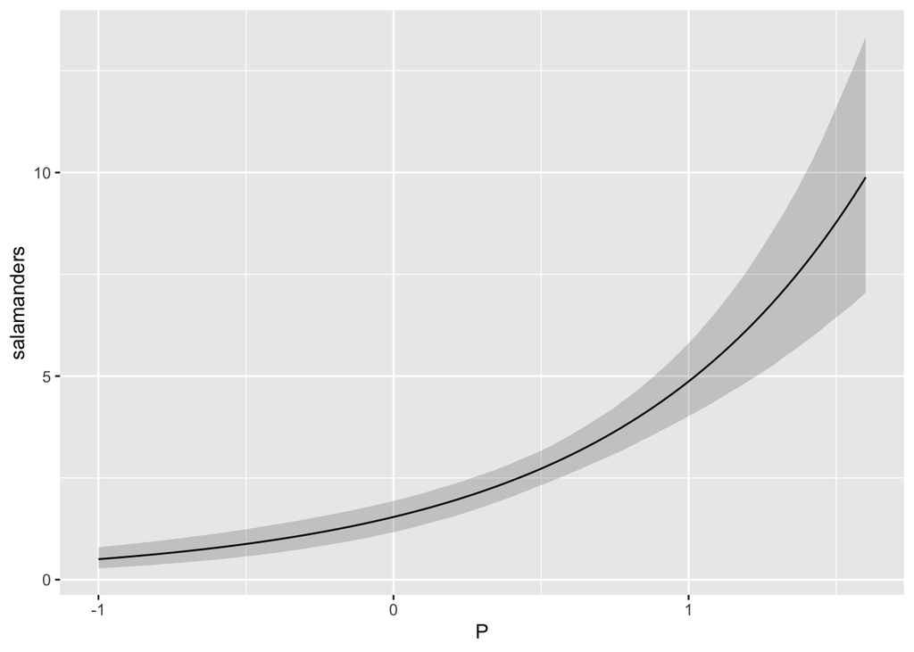

```r
sim_dat<-data.frame(P = seq(-1, 1.6, by = 0.01))
post<-link(m1, sim_dat)
sim_dat<-sim_dat %>%
  mutate(salamanders = apply(post, 2, mean),
         s_hi = apply(post, 2, PI)[2,],
         s_lo = apply(post, 2, PI)[1,])
ggplot(sim_dat,
       aes(x = P, y = salamanders,
           ymin = s_lo,
           ymax = s_hi)) +
  geom_line()+
  geom_ribbon(alpha = 0.2)
```

```r
m2<-ulam(alist(
  SALAMAN ~ dpois(l),
  log(l) <- a + b * P + b2 * FA,
  a ~ dnorm(0, 1),
  b ~ dnorm(0, 1),
  b2 ~ dnorm(0, 1)
), data = d, chains = 4, cores = 4, log_lik = T)
```

```
## Trying to compile a simple C file
```

[output not shown]

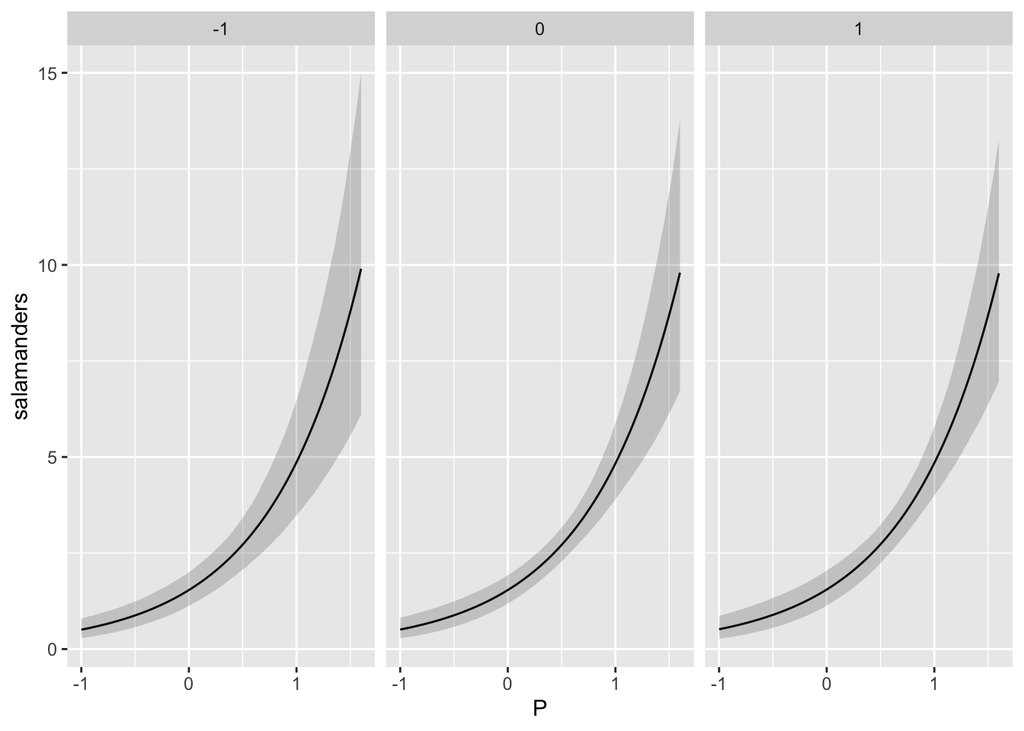

```r
sim_dat<-data.frame(P = rep(seq(-1, 1.6, by = 0.01), 3),
                    FA = rep(c(-1, 0, 1), each = 261))
post<-link(m2, sim_dat)
sim_dat<-sim_dat %>%
  mutate(salamanders = apply(post, 2, mean),
         s_hi = apply(post, 2, PI)[2,],
         s_lo = apply(post, 2, PI)[1,])
ggplot(sim_dat,
       aes(x = P, y = salamanders,
           ymin = s_lo,
           ymax = s_hi)) +
  geom_line()+
  geom_ribbon(alpha = 0.2) +
  facet_wrap(~FA)
```

The predictions are indistinguishable across various values of forest age. I think we can safely say it isn’t providing much information on salamander density.